# Introduction

The company Elektra operates within the Manufacturing Industry, with a specialized focus on the production of electrical cables and conductors. They have a wide variety of products catering to various sectors such as automotive, energy, home appliances, and more. Additionally, they have a goal of leading the energy transmission market and plan on becoming a key player in the manufacturing sector.

## Table showing type of variables

## **Research Question:**

Q)Can we predict the likelihood of unsafe acts (**ACA**) based on the operator's professional profile (**AGE_OPERATOR**, **EMPLOYEE_CAT**, **YEARS_EXP**) and work environment factors (**USE_PPE**, **AVAILABLE_SPACE**)?

This question would help us understand the biggest concern about safety that is faced by the company.

```python
import pandas as pd
data = {
    'Variable Name': ['ID_LINE', 'AGE_OPERATOR', 'YEARS_EXP', 'SENIORITY', 'EMPLOYEE_CAT',
                      'HOURS_OFTRAINING_SECURITY', 'HOURS_OFTRAINING_POSITION', 'GRADE_TEOREXAM',
                      'GRADE_PRACTICALEXAM', 'NUMBER_ILLS', 'SCORE_RISKOFMACH', 'SCORE_ILLUM',
                      'NOISE_ATPLACE', 'NUMBER_EXTRAHOURS', 'NUMBER_RESTHOURS', 'SCORE_HIDRAT',
                      'USE_PPE', 'USE_ADEQTOOLS', 'SUFFER_ANXIETY', 'EXPOSED_QUIM', 'AVAILABLE_SPACE',
                      'SCORE_FATIGUE', 'EVAL_TIMEAVAIL', 'EVAL_KNOWSUFFIC', 'TEMP_PLACEOFWORK', 'ACA'],
    'Measurement Type': ['Nominal', 'Ratio', 'Ratio', 'Ratio', 'Ordinal',
                         'Ratio', 'Ratio', 'Scale', 'Scale', 'Ratio', 'Scale', 'Scale',
                         'Ratio', 'Ratio', 'Ratio', 'Scale', 'Nominal', 'Nominal', 'Nominal', 'Scale', 'Scale',
                         'Scale', 'Scale', 'Scale', 'Ratio', 'Ratio'],
    'Variable Role': ['Excluded', 'Predictor', 'Predictor', 'Predictor', 'Predictor',
                      'Predictor', 'Predictor', 'Predictor', 'Predictor', 'Predictor', 'Outcome', 'Predictor',
                      'Predictor', 'Predictor', 'Predictor', 'Predictor', 'Predictor', 'Predictor', 'Predictor', 'Predictor', 'Predictor',
                      'Predictor', 'Predictor', 'Predictor', 'Predictor', 'Outcome']
}
df = pd.DataFrame(data)
from IPython.display import display
display(df)
```

|  | Variable Name | Measurement Type | Variable Role |
| --- | --- | --- | --- |
| 0 | ID_LINE | Nominal | Excluded |
| 1 | AGE_OPERATOR | Ratio | Predictor |
| 2 | YEARS_EXP | Ratio | Predictor |
| 3 | SENIORITY | Ratio | Predictor |
| 4 | EMPLOYEE_CAT | Ordinal | Predictor |
| 5 | HOURS_OFTRAINING_SECURITY | Ratio | Predictor |
| 6 | HOURS_OFTRAINING_POSITION | Ratio | Predictor |
| 7 | GRADE_TEOREXAM | Scale | Predictor |
| 8 | GRADE_PRACTICALEXAM | Scale | Predictor |
| 9 | NUMBER_ILLS | Ratio | Predictor |
| 10 | SCORE_RISKOFMACH | Scale | Outcome |
| 11 | SCORE_ILLUM | Scale | Predictor |
| 12 | NOISE_ATPLACE | Ratio | Predictor |
| 13 | NUMBER_EXTRAHOURS | Ratio | Predictor |
| 14 | NUMBER_RESTHOURS | Ratio | Predictor |
| 15 | SCORE_HIDRAT | Scale | Predictor |
| 16 | USE_PPE | Nominal | Predictor |
| 17 | USE_ADEQTOOLS | Nominal | Predictor |
| 18 | SUFFER_ANXIETY | Nominal | Predictor |
| 19 | EXPOSED_QUIM | Scale | Predictor |
| 20 | AVAILABLE_SPACE | Scale | Predictor |
| 21 | SCORE_FATIGUE | Scale | Predictor |
| 22 | EVAL_TIMEAVAIL | Scale | Predictor |
| 23 | EVAL_KNOWSUFFIC | Scale | Predictor |
| 24 | TEMP_PLACEOFWORK | Ratio | Predictor |
| 25 | ACA | Ratio | Outcome |

```python
#importing the required libraries
import numpy as np
import pandas as pd
from sklearn.model_selection import train_test_split, cross_val_score
from sklearn.preprocessing import StandardScaler
from sklearn.linear_model import LinearRegression, LogisticRegression, Lasso
from sklearn.ensemble import RandomForestRegressor, RandomForestClassifier, GradientBoostingClassifier
from sklearn.metrics import mean_squared_error, accuracy_score, confusion_matrix, classification_report
from sklearn.svm import SVC
import matplotlib.pyplot as plt
import seaborn as sns
from sklearn.model_selection import GridSearchCV
```

```python
# Loading the dataset
df = pd.read_excel('/content/PLANT_SECURITY_SV (1).xlsx', sheet_name='DB')
```

```python
# Displaying the first few rows of the dataset
print(df.head())
```

```
           ID_LINE  AGE_OPERATOR  YEARS_EXP  SENIORITY  EMPLOYEE_CAT  \
0       189399M851            36          6          6             6
1      2133265M301            19          1          1             6
2       32695VZF81            39         10         21             6
3      4147823VZ81            22          1          1             7
4  5106984MZV7/1 1            26          1          4             6

   HOURS_OFTRAINING_SECURITY  HOURS_OFTRAINING_POSITION  GRADE_TEOREXAM  \
0                       14.5                         38             100
1                       14.5                         22              95
2                       14.5                         38             100
3                       14.5                         10              90
4                       14.5                         38             100

   GRADE_PRACTICALEXAM  NUMBER_ILLS  ...  USE_ADEQTOOLS  SUFFER?ANXIETY  \
```

[output cut: 21 more lines]

```python
# Checking for missing values
print(df.isnull().sum())
```

```
ID_LINE                      0
AGE_OPERATOR                 0
YEARS_EXP                    0
SENIORITY                    0
EMPLOYEE_CAT                 0
HOURS_OFTRAINING_SECURITY    0
HOURS_OFTRAINING_POSITION    0
GRADE_TEOREXAM               0
GRADE_PRACTICALEXAM          0
NUMBER_ILLS                  0
SCORE_RISKOFMACH             0
SCORE_ILLUM                  0
NOISE_ATPLACE                0
NUMBER_EXTRAHOURS            0
NUMBER_RESTHOURS             0
SCORE_HIDRAT                 0
USE_PPE                      0
USE_ADEQTOOLS                0
SUFFER?ANXIETY               0
EXPOSED_QUIM                 0
SCORE_ILLUM.1                0
AVAILABLE_SPACE              0
SCORE_FATIGUE                0
EVAL_TIMEAVAIL               0
EVAL_KNOWSUFFIC              0
TEMP_PLACEOFWORK             0
ACA                          0
dtype: int64
```

```python
# Summary statistics for the numerical variables
print(df.describe())
```

```
       AGE_OPERATOR   YEARS_EXP   SENIORITY  EMPLOYEE_CAT  \
count    865.000000  865.000000  865.000000    865.000000
mean      35.958382    3.579191    7.972254      5.395376
std        9.693241    3.100333    6.562320      1.248509
min       19.000000    1.000000    1.000000      2.000000
25%       28.000000    1.000000    2.000000      5.000000
50%       34.000000    2.000000    7.000000      6.000000
75%       44.000000    6.000000   15.000000      6.000000
max       57.000000   10.000000   21.000000      7.000000

       HOURS_OFTRAINING_SECURITY  HOURS_OFTRAINING_POSITION  GRADE_TEOREXAM  \
count                      865.0                 865.000000      865.000000
mean                        14.5                  33.535260       97.115607
std                          0.0                   7.859382        5.020610
min                         14.5                  10.000000       80.000000
25%                         14.5                  32.000000       95.000000
50%                         14.5                  38.000000      100.000000
75%                         14.5                  38.000000      100.000000
max                         14.5                  38.000000      100.000000

       GRADE_PRACTICALEXAM  NUMBER_ILLS  SCORE_RISKOFMACH  ...  USE_ADEQTOOLS  \
count           865.000000   865.000000        865.000000  ...     865.000000
mean             97.358382     1.658960        821.669503  ...       0.708671
std               4.911120     1.154898        170.550540  ...       0.454638
min              80.000000     0.000000        623.100000  ...       0.000000
25%              95.000000     1.000000        623.800000  ...       0.000000
50%             100.000000     2.000000        789.000000  ...       1.000000
75%             100.000000     3.000000        868.000000  ...       1.000000
max             100.000000     4.000000       1072.000000  ...       1.000000

       SUFFER?ANXIETY  EXPOSED_QUIM  SCORE_ILLUM.1  AVAILABLE_SPACE  \
count      865.000000    865.000000     865.000000       865.000000
mean         0.223121      2.395376       4.223121         4.083237
std          0.416580      1.197403       0.745308         0.868699
min          0.000000      1.000000       2.000000         1.000000
25%          0.000000      1.000000       4.000000         4.000000
50%          0.000000      2.000000       4.000000         4.000000
75%          0.000000      3.000000       5.000000         5.000000
max          1.000000      5.000000       5.000000         5.000000

       SCORE_FATIGUE  EVAL_TIMEAVAIL  EVAL_KNOWSUFFIC  TEMP_PLACEOFWORK  \
count     865.000000      865.000000       865.000000        865.000000
mean        2.690173        3.937572         3.953757         36.537688
std         1.300359        0.823996         0.961137          1.313442
min         1.000000        1.000000         1.000000         33.700000
25%         2.000000        4.000000         4.000000         35.400000
50%         2.000000        4.000000         4.000000         37.000000
75%         4.000000        4.000000         5.000000         37.500000
max         5.000000        5.000000         5.000000         39.000000

              ACA
count  865.000000
mean     1.026590
std      2.825641
min      0.000000
25%      0.000000
50%      0.000000
75%      1.000000
max     63.000000

[8 rows x 26 columns]
```

```python
#Checking the datatypes
dp=df.dtypes
print(dp)
```

```
ID_LINE                       object
AGE_OPERATOR                   int64
YEARS_EXP                      int64
SENIORITY                      int64
EMPLOYEE_CAT                   int64
HOURS_OFTRAINING_SECURITY    float64
HOURS_OFTRAINING_POSITION      int64
GRADE_TEOREXAM                 int64
GRADE_PRACTICALEXAM            int64
NUMBER_ILLS                    int64
SCORE_RISKOFMACH             float64
SCORE_ILLUM                  float64
NOISE_ATPLACE                float64
NUMBER_EXTRAHOURS            float64
NUMBER_RESTHOURS             float64
SCORE_HIDRAT                   int64
USE_PPE                        int64
USE_ADEQTOOLS                  int64
SUFFER?ANXIETY                 int64
EXPOSED_QUIM                   int64
SCORE_ILLUM.1                  int64
AVAILABLE_SPACE                int64
SCORE_FATIGUE                  int64
EVAL_TIMEAVAIL                 int64
EVAL_KNOWSUFFIC                int64
TEMP_PLACEOFWORK             float64
ACA                            int64
dtype: object
```

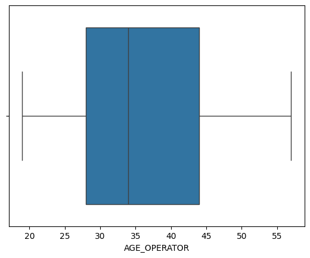

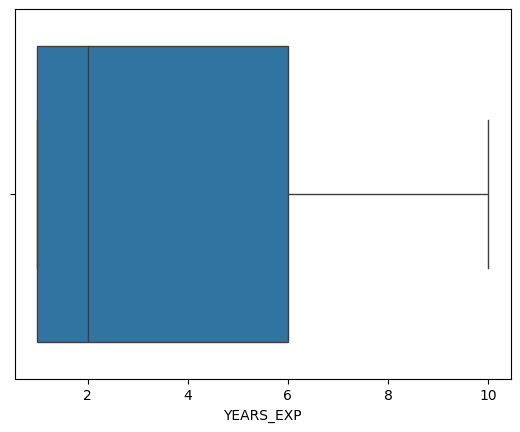

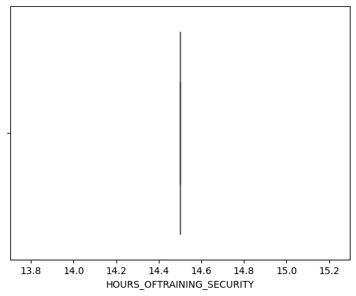

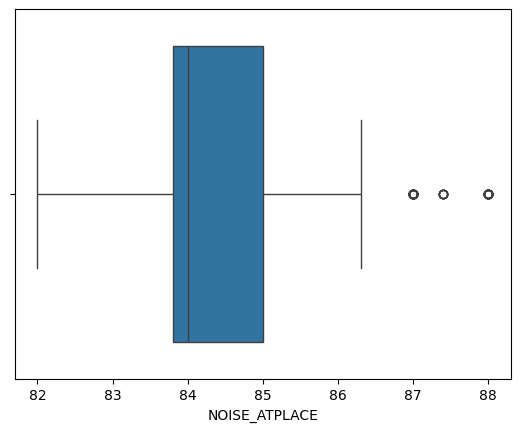

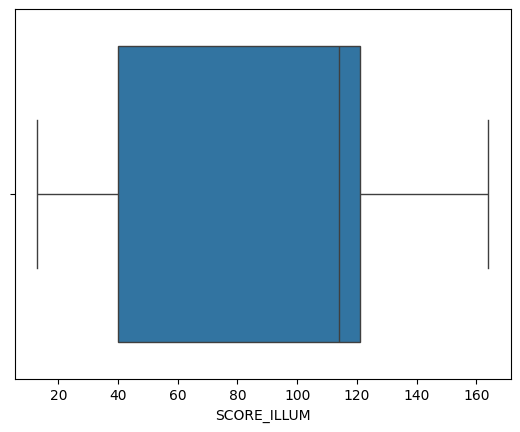

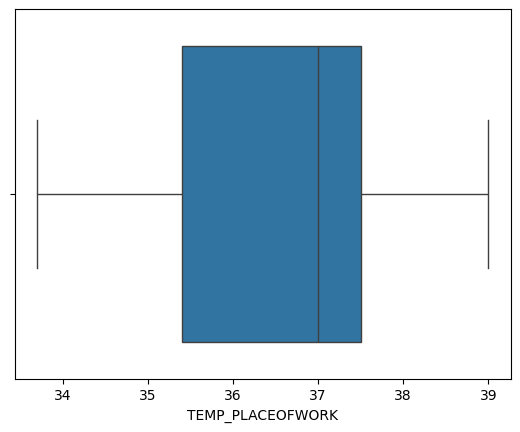

```python
# Checking for outliers using boxplots
numerical_vars = ['AGE_OPERATOR', 'YEARS_EXP', 'HOURS_OFTRAINING_SECURITY', 'NOISE_ATPLACE', 'SCORE_ILLUM', 'TEMP_PLACEOFWORK']
for var in numerical_vars:
    sns.boxplot(x=df[var])
    plt.show()
```

# Exploratry Data Analysis

## Observations

We can see that there are no significant outliers or any null values in any of the variables considered. We can see that all the workers have gone through 14.5 hours of mandatory safety trainings. The only outliers are found in the Noise at place variable, which we can interview on a case by case basis.

## Handling Variables

**Excluded Variables:** ID_LINE has been excluded as it serves as an identifier rather than a feature that influences outcomes.

**Predictor Variables:** AGE_OPERATOR, YEARS_EXP, and HOURS_OFTRAINING_SECURITY are typical predictors as they describe the operator’s background and experience, which influences performance and safety.

**Outcome Variables:** SCORE_RISKOFMACH and ACA are outcomes because they are direct measures of safety.

```python
 #Convert categorical variables to numeric.
 #df = pd.get_dummies(df, columns=['EMPLOYEE_CAT'], drop_first=True)  # Example for categorical conversion
```

We are keeping Employee_Cat as an numeric variables as it has a linear relationship with ACA and it is a trade-off we accept as dummy coding into different categories can lead to more complex and less interpretable models.

```python
# Convert 'ACA' from numerical to categorical (0 or 1)
df['ACA'] = (df['ACA'] > 0).astype(int)

# This line checks each 'ACA' value to see if it's greater than 0. If so, it becomes 1; otherwise, it stays as 0.
# The .astype(int) ensures the result is an integer (0 or 1).

# Quick check to see the transformation
print(df['ACA'].value_counts())
```

```
0    646
1    219
Name: ACA, dtype: int64
```

We have converted the ACA from a numerical to categorical variable which represents if a unsafe incident has occured or not. This would help us take a look at variables which effect these incidents.

# Building Predictive Models.

X variable would contain all the features we are considering and the Y variable contains our outcome variable. We will be spliting the X and Y variable as train and test samples with 0.8:0.2 ratio.

### Logistic Regression with LASSO

```python
# Defining features and target variables
X = df[['AGE_OPERATOR', 'EMPLOYEE_CAT', 'YEARS_EXP', 'USE_PPE', 'AVAILABLE_SPACE']]
y = df['ACA'] > 0  # Assuming ACA > 0 indicates unsafe acts, making it a binary outcome

# Spliting the dataset into training and testing sets
X_train, X_test, y_train, y_test = train_test_split(X, y, test_size=0.2, random_state=42)

# Standardize the features
scaler = StandardScaler()
X_train_scaled = scaler.fit_transform(X_train)
X_test_scaled = scaler.transform(X_test)

# Initialize and train the Logistic Regression model with LASSO penalty
log_reg_lasso = LogisticRegression(penalty='l1', solver='liblinear', random_state=42)
log_reg_lasso.fit(X_train_scaled, y_train)

# Predictions and Evaluation
y_pred = log_reg_lasso.predict(X_test_scaled)
print("Classification Report for Logistic Regression with LASSO:\n", classification_report(y_test, y_pred))
print("Confusion Matrix:\n", confusion_matrix(y_test, y_pred))
```

```
Classification Report for Logistic Regression with LASSO:
               precision    recall  f1-score   support

       False       0.80      0.99      0.88       135
        True       0.67      0.11      0.18        38

    accuracy                           0.79       173
   macro avg       0.73      0.55      0.53       173
weighted avg       0.77      0.79      0.73       173

Confusion Matrix:
 [[133   2]
 [ 34   4]]
```

### Building Random Forest Model

```python
# Initialize and train the Random Forest model
random_forest = RandomForestClassifier(n_estimators=100, random_state=42)
random_forest.fit(X_train_scaled, y_train)

# Predictions and Evaluation
y_pred_rf = random_forest.predict(X_test_scaled)
print("Classification Report for Random Forest:\n", classification_report(y_test, y_pred_rf))
print("Confusion Matrix:\n", confusion_matrix(y_test, y_pred_rf))
```

```
Classification Report for Random Forest:
               precision    recall  f1-score   support

       False       0.80      0.85      0.83       135
        True       0.33      0.26      0.29        38

    accuracy                           0.72       173
   macro avg       0.57      0.56      0.56       173
weighted avg       0.70      0.72      0.71       173

Confusion Matrix:
 [[115  20]
 [ 28  10]]
```

### Building SVM

#### Building bivariate pair plots.

This method helps us identify the best kernel to use. I have talked about another method further down below.

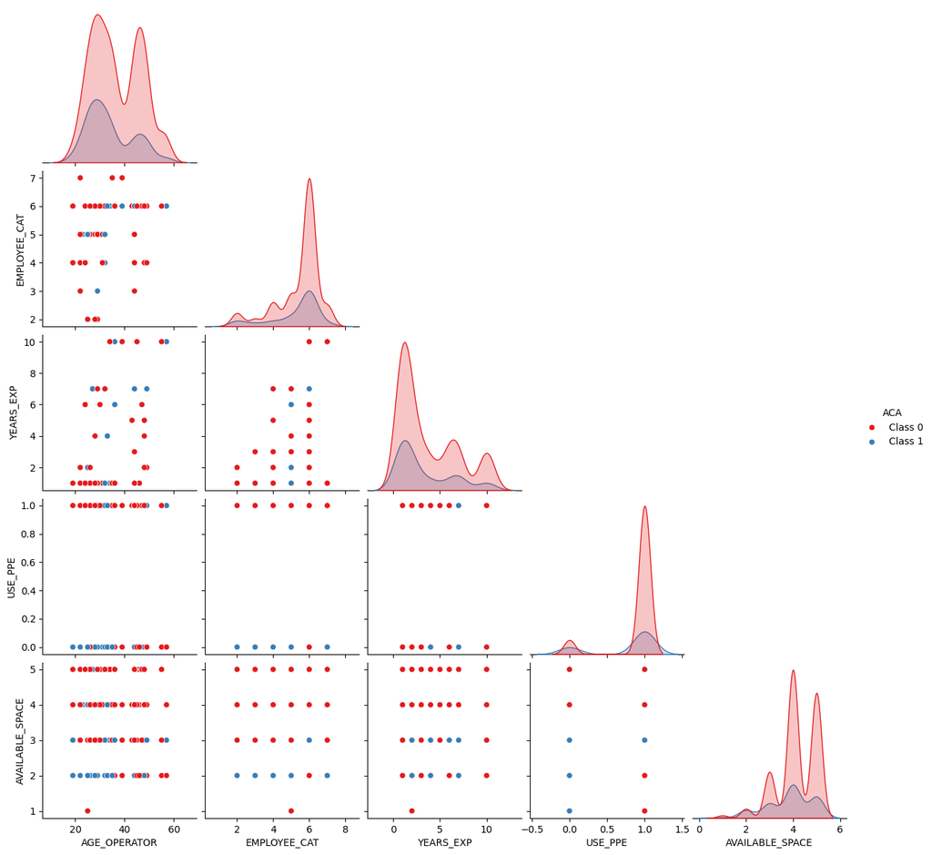

```python
import seaborn as sns
import matplotlib.pyplot as plt

# Assuming 'df' is your DataFrame and contains the features and target
# Create a temporary column for visualization
df['ACA_vis'] = df['ACA'].apply(lambda x: 'Class 0' if x == 0 else 'Class 1')

# Assuming features is a list of your feature column names
features = ['AGE_OPERATOR', 'EMPLOYEE_CAT', 'YEARS_EXP', 'USE_PPE', 'AVAILABLE_SPACE']

# Generate the pair plot using the temporary column for coloring
sns.pairplot(df[features + ['ACA_vis']], hue='ACA_vis', palette='Set1', corner=True)
plt.show()

# Remove the temporary column after visualization
df.drop('ACA_vis', axis=1, inplace=True)
```

Based on this bivariate plot we can deduce that polyinomial variable make sense.

```python
# Create the SVM model with the optimal hyperparameters
optimal_svm = SVC(C=1, gamma='scale', kernel='poly', random_state=42)

# Fit the model on the entire training set
optimal_svm.fit(X_train_scaled, y_train)

# Make predictions on the test set
y_pred_svm_optimal = optimal_svm.predict(X_test_scaled)

# Evaluate the model
accuracy_svm_optimal = accuracy_score(y_test, y_pred_svm_optimal)
print("Test set accuracy for SVM with optimal hyperparameters:", accuracy_svm_optimal)

# Predictions and Evaluation
print("Classification Report for Logistic Regression with LASSO:\n", classification_report(y_test, y_pred))


# Confusion Matrix for SVM with optimal hyperparameters
cm_svm_optimal = confusion_matrix(y_test, y_pred_svm_optimal)
print("Confusion Matrix for SVM with optimal hyperparameters:\n", cm_svm_optimal)
```

```
Test set accuracy for SVM with optimal hyperparameters: 0.8034682080924855
Classification Report for Logistic Regression with LASSO:
               precision    recall  f1-score   support

       False       0.80      0.99      0.88       135
        True       0.67      0.11      0.18        38

    accuracy                           0.79       173
   macro avg       0.73      0.55      0.53       173
weighted avg       0.77      0.79      0.73       173

Confusion Matrix for SVM with optimal hyperparameters:
 [[132   3]
 [ 31   7]]
```

## Assessing model performance

Use k-fold cross-validation, for: tuning the model's parameters (hyper-parameters) and identifying the best combination, assessing the aggregated predictive error on the training set.

### Optimal parameters for Logistic Regression with Lasso.

```python
# Define parameter grid for Logistic Regression
param_grid_lr = {'C': [0.01, 0.1, 1, 10, 100]}

# Initialize the model
log_reg_lasso = LogisticRegression(penalty='l1', solver='liblinear', random_state=42)

# Setup GridSearchCV
grid_search_lr = GridSearchCV(log_reg_lasso, param_grid_lr, cv=5, scoring='accuracy', return_train_score=True)

# Fit the model
grid_search_lr.fit(X_train_scaled, y_train)

# Best parameters and scores
print("Best parameters for Logistic Regression:", grid_search_lr.best_params_)
print("Best cross-validation score (Accuracy):", grid_search_lr.best_score_)
```

```
Best parameters for Logistic Regression: {'C': 1}
Best cross-validation score (Accuracy): 0.7486184965071422
```

## Optimal parameters for Random Forest

```python
# Define parameter grid for Random Forest
param_grid_rf = {
    'n_estimators': [10, 50, 100],
    'max_depth': [None, 10, 20, 30]
}

# Initialize the model
random_forest = RandomForestClassifier(random_state=42)

# Setup GridSearchCV
grid_search_rf = GridSearchCV(random_forest, param_grid_rf, cv=5, scoring='accuracy', return_train_score=True)

# Fit the model
grid_search_rf.fit(X_train_scaled, y_train)

# Best parameters and scores
print("Best parameters for Random Forest:", grid_search_rf.best_params_)
print("Best cross-validation score (Accuracy):", grid_search_rf.best_score_)
```

```
Best parameters for Random Forest: {'max_depth': 10, 'n_estimators': 100}
Best cross-validation score (Accuracy): 0.712501303305182
```

```python
from sklearn.svm import SVC

# Define parameter grid for SVM
param_grid_svm = {
    'C': [0.1, 1, 10],
    'gamma': [0.001, 0.01, 0.1, 'scale'],  # 'scale' is the default value for gamma
    'kernel': ['poly']  # Radial Basis Function (RBF) kernel; you can try others like 'linear', 'poly'
}

# Initialize the model
svm = SVC(random_state=42)

# Setup GridSearchCV for SVM
grid_search_svm = GridSearchCV(svm, param_grid_svm, cv=5, scoring='accuracy', n_jobs=-1)

# Fit the model
grid_search_svm.fit(X_train_scaled, y_train)

# Report the best parameters
print("Optimal hyperparameters for SVM:", grid_search_svm.best_params_)
```

```
Optimal hyperparameters for SVM: {'C': 1, 'gamma': 'scale', 'kernel': 'poly'}
```

## Optimal parameters for SVM

We can run all the SVM's together to identify the best kernel. This is a brute force way of choosing the best kernel for our particular dataset.

```python
from sklearn.model_selection import cross_val_score

# Define the feature matrix X and target vector y from your dataset
X_scaled = scaler.fit_transform(X)  # Assuming X is your feature matrix
y = df['ACA'] > 0  # Example target based on your previous questions

# Initialize SVM models with different kernels
svm_linear = SVC(kernel='linear', C=1)
svm_poly = SVC(kernel='poly', C=1, gamma='scale')
svm_rbf = SVC(kernel='rbf', C=1, gamma='scale')

# Perform cross-validation and compute the mean accuracy for each kernel
cv_accuracy_linear = cross_val_score(svm_linear, X_scaled, y, cv=5, scoring='accuracy').mean()
cv_accuracy_poly = cross_val_score(svm_poly, X_scaled, y, cv=5, scoring='accuracy').mean()
cv_accuracy_rbf = cross_val_score(svm_rbf, X_scaled, y, cv=5, scoring='accuracy').mean()

# Print the results
print(f"Mean CV Accuracy (Linear Kernel): {cv_accuracy_linear}")
print(f"Mean CV Accuracy (Polynomial Kernel): {cv_accuracy_poly}")
print(f"Mean CV Accuracy (RBF Kernel): {cv_accuracy_rbf}")
```

```
Mean CV Accuracy (Linear Kernel): 0.7341040462427746
Mean CV Accuracy (Polynomial Kernel): 0.7653179190751445
Mean CV Accuracy (RBF Kernel): 0.7606936416184971
```

As we can see polynomial kernel offers the best accuracy and correlates with the bivariate plots from before making it our best option.

## Using the testing set for computing each model's predictive performance.

```python
# evaluation for Logistic Regression with the best parameters
y_pred_lr = grid_search_lr.best_estimator_.predict(X_test_scaled)
print("Test set accuracy for Logistic Regression:", accuracy_score(y_test, y_pred_lr))

# Using the best estimator from GridSearchCV for Random Forest
y_pred_rf = grid_search_rf.best_estimator_.predict(X_test_scaled)

# Calculate the accuracy score for Random Forest on the test set
accuracy_rf = accuracy_score(y_test, y_pred_rf)

# Print the test set accuracy for Random Forest
print("Test set accuracy for Random Forest:", accuracy_rf)

# Using the best estimator from GridSearchCV for SVM
y_pred_svm = grid_search_svm.best_estimator_.predict(X_test_scaled)

# Calculate the accuracy score for SVM on the test set
accuracy_svm = accuracy_score(y_test, y_pred_svm)

# Print the test set accuracy for SVM
print("Test set accuracy for SVM:", accuracy_svm)
```

```
Test set accuracy for Logistic Regression: 0.791907514450867
Test set accuracy for Random Forest: 0.7283236994219653
Test set accuracy for SVM: 0.8034682080924855
```

After using the hold-out test set and using those to verify the accuracy of the multiple models we could see that SVM is the most accurate.

# Reporting the results

```python
from sklearn.metrics import confusion_matrix

def display_confusion_matrix(y_true, y_pred):
    cm = confusion_matrix(y_true, y_pred)
    tn, fp, fn, tp = cm.ravel()
    print(f"True Negatives: {tn}")
    print(f"False Positives: {fp}")
    print(f"False Negatives: {fn}")
    print(f"True Positives: {tp}")
    return cm
```

```python
# Optimal hyperparameters
print("Optimal hyperparameters for Logistic Regression:", grid_search_lr.best_params_)

# Metrics
accuracy_lr = accuracy_score(y_test, y_pred_lr)
print("Accuracy for Logistic Regression:", accuracy_lr)

# Confusion Matrix
cm_lr = display_confusion_matrix(y_test, y_pred_lr)

# Variable Importance (Coefficient magnitude)
coefficients = grid_search_lr.best_estimator_.coef_.flatten()
features = X.columns
feature_importance_lr = pd.Series(coefficients, index=features).sort_values(key=abs, ascending=False)
print("Feature importance for Logistic Regression:\n", feature_importance_lr)
```

```
Optimal hyperparameters for Logistic Regression: {'C': 1}
Accuracy for Logistic Regression: 0.791907514450867
True Negatives: 133
False Positives: 2
False Negatives: 34
True Positives: 4
Feature importance for Logistic Regression:
 USE_PPE           -0.325905
AGE_OPERATOR      -0.283476
AVAILABLE_SPACE   -0.234148
EMPLOYEE_CAT      -0.147085
YEARS_EXP          0.141227
dtype: float64
```

```python
# Optimal hyperparameters
print("Optimal hyperparameters for Random Forest:", grid_search_rf.best_params_)

# Predictions using the best estimator
y_pred_rf = grid_search_rf.best_estimator_.predict(X_test_scaled)

# Metrics
accuracy_rf = accuracy_score(y_test, y_pred_rf)
print("Accuracy for Random Forest:", accuracy_rf)

# Confusion Matrix
cm_rf = display_confusion_matrix(y_test, y_pred_rf)

# Variable Importance
importances_rf = grid_search_rf.best_estimator_.feature_importances_
feature_importance_rf = pd.Series(importances_rf, index=features).sort_values(ascending=False)
print("Feature importance for Random Forest:\n", feature_importance_rf)
```

```
Optimal hyperparameters for Random Forest: {'max_depth': 10, 'n_estimators': 100}
Accuracy for Random Forest: 0.7283236994219653
True Negatives: 118
False Positives: 17
False Negatives: 30
True Positives: 8
Feature importance for Random Forest:
 AGE_OPERATOR       0.356825
AVAILABLE_SPACE    0.190483
EMPLOYEE_CAT       0.188259
YEARS_EXP          0.163764
USE_PPE            0.100668
dtype: float64
```

```python
from sklearn.metrics import accuracy_score, confusion_matrix
import matplotlib.pyplot as plt
import seaborn as sns

# Assuming display_confusion_matrix is defined as before

# Optimal hyperparameters
print("Optimal hyperparameters for SVM:", grid_search_svm.best_params_)

# Predictions using the best estimator
y_pred_svm = grid_search_svm.best_estimator_.predict(X_test_scaled)

# Metrics
accuracy_svm = accuracy_score(y_test, y_pred_svm)
print("Accuracy for SVM:", accuracy_svm)

# Confusion Matrix
cm_svm = display_confusion_matrix(y_test, y_pred_svm)

# Unfortunately, direct feature importance is not available for non-linear SVM.
# For linear SVM, you could look at the absolute values of the coefficients:
if 'linear' == grid_search_svm.best_params_['kernel']:
    svm_coefs = grid_search_svm.best_estimator_.coef_.flatten()
    feature_importance_svm = pd.Series(abs(svm_coefs), index=features).sort_values(ascending=False)
    print("Feature importance for linear SVM:\n", feature_importance_svm)
else:
    print("Feature importance is not directly interpretable for non-linear kernels.")
```

```
Optimal hyperparameters for SVM: {'C': 1, 'gamma': 'scale', 'kernel': 'poly'}
Accuracy for SVM: 0.8034682080924855
True Negatives: 132
False Positives: 3
False Negatives: 31
True Positives: 7
Feature importance is not directly interpretable for non-linear kernels.
```

```python
from sklearn.metrics import classification_report

# For Logistic Regression
print("Classification Report for Logistic Regression:")
print(classification_report(y_test, y_pred_lr))

# For Random Forest
print("Classification Report for Random Forest:")
print(classification_report(y_test, y_pred_rf))

# For SVM
print("Classification Report for SVM:")
print(classification_report(y_test, y_pred_svm))
```

[output not shown]

# Interpreting the results from the assesment

When evaluating models for a categorical outcome(ACA), it's crucial to consider other metrics beyond simple accuracy. Given the results from Logistic Regression (with LASSO), Random Forest, and SVM with a polynomial kernel, a more in-depth approach to model comparison is warranted. Accuracy, while providing a quick snapshot of overall model performance, does not account for the specific types of errors a model makes. This is where confusion matrix metrics—true positives (TP), true negatives (TN), false positives (FP), and false negatives (FN)—become invaluable.

Variable importance metrics provided for Logistic Regression and Random Forest offer insights into which features most significantly influence the model's predictions. For Logistic Regression, features like USE_PPE, AGE_OPERATOR, and AVAILABLE_SPACE are highlighted, with USE_PPE showing a notably negative impact. This suggests that the use of personal protective equipment (PPE) significantly decreases the likelihood of the outcome being predicted, perhaps indicating safer work practices. Conversely, Random Forest identifies AGE_OPERATOR as the most critical feature, suggesting that an operator's age is a significant predictor of outcomes in this context. Such insights are invaluable for understanding the underlying patterns in the data and can inform targeted interventions or further feature engineering.

Analyzing the classification reports for Logistic Regression, Random Forest, and SVM reveals nuanced insights into each model's performance, particularly when dissecting precision, recall, and F1-scores across the classes. The SVM model exhibits a superior precision of 0.70 for the positive class, indicating a higher likelihood of its positive predictions being accurate, a crucial metric in scenarios where the cost of false positives is significant. However, all models demonstrate challenges with recall for the positive class, with SVM achieving a recall of 0.18, suggesting that it correctly identifies only 18% of all actual positive instances. This is a critical area of concern in applications where missing positive instances could have dire consequences, such as in medical diagnostics or fraud detection. The F1-score, which balances precision and recall, is comparably higher for SVM and Random Forest for the positive class, signifying a relatively better performance in handling the positive class than Logistic Regression, albeit still leaving room for improvement.

The overall accuracy of the models paints a somewhat misleading picture due to the likely class imbalance, with SVM slightly leading in this metric. However, the essence of choosing the most appropriate model hinges on the specific application's needs and the relative costs associated with false positives versus false negatives. Given the metrics, SVM emerges as the preferable model for contexts prioritizing precision and minimizing false positives. Nonetheless, the relatively low recall across all models underscores a shared difficulty in capturing all positive instances, emphasizing the need for further model tuning, exploration of alternative features, or adoption of ensemble methods to enhance model sensitivity without compromising precision unduly.

# Conclusion

Based on the provided metrics for Logistic Regression, Random Forest, and SVM (with a polynomial kernel), let's analyze the models' ranking, discuss their strengths and weaknesses, and conclude on variable importance and recommended approaches under different objectives.

### Strengths and Weaknesses

- **SVM:** Strengths include its flexibility in handling non-linear data through kernel trick and achieving high accuracy. The weakness might be its computational complexity, especially with non-linear kernels and larger datasets, which could affect model training and tuning time.
- **Logistic Regression:** Its strength lies in simplicity, interpretability, and fast computation, making it suitable for problems with linear relationships. However, it struggles with non-linear data and complex interactions between features.
- **Random Forest:** Offers robustness against overfitting due to its ensemble approach and can capture complex relationships and interactions between features. Its weakness includes potential for high variance if not properly tuned and longer training times due to building multiple trees.

### Recommendations

- **For the "Best" Predictive Performance:** SVM with a polynomial kernel is recommended due to its superior accuracy and ability to handle complex, non-linear associations. This choice is optimal when model performance is paramount, and computational resources and time are sufficient.
- **For a Good Enough Solution Quickly:** Logistic Regression is advisable. It offers competitive accuracy, faster training times, and the advantage of interpretability. It's suitable when the relationships in the data are relatively linear, or when a quick, understandable model is needed.

### Conclusion

The choice of modeling approach should align with the specific objectives, the computational resources available, and the importance of model interpretability. SVM is preferable for maximizing predictive performance, especially in complex datasets with non-linear patterns. In contrast, Logistic Regression provides a quick, interpretable model that can suffice in scenarios where speed and simplicity are more critical than achieving the utmost accuracy. Random Forest stands out when feature interactions and model robustness are key considerations, despite potentially longer training times.